# STAT 205 HW4

HONGLEI REN

03/04/2020

# EX 9.21

### (a) Data analysis

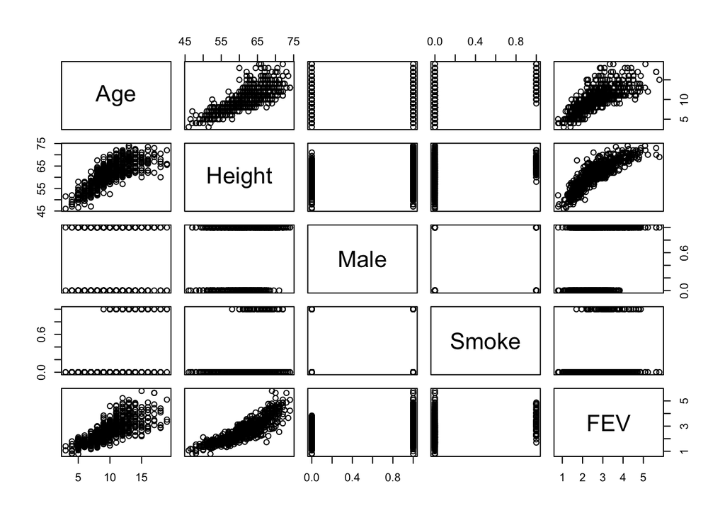

```r
  FEVdata <- read.table(file="FullFEVdata.txt",header=T, sep="")
  attach(FEVdata)
  pairs(~Age+Hgt+Male+Smoke+FEV,labels=c("Age","Height","Male","Smoke","FEV"),data=FEVdata)
```

### (b) Prior, Predictors and Model Diagnosis

#### 1) Predictor selection

```r
  Age.st=standardize(Age)
  FEV.st=standardize(FEV)
  X.mat=model.matrix(~ as.factor(Smoke) + Age.st  + as.factor(Smoke)*Age.st)
```

#### 2) Prior Construction

Here, I apply the BCJ independent priors for $\beta$ and $\tau$. According to the given prior knowledge from Dr. David. We have:

$$\widetilde{X} = \begin{bmatrix}
\widetilde{x_1}'\\
\widetilde{x_2}'\\
\widetilde{x_3}'\\
\widetilde{x_4}'
\end{bmatrix}= \begin{bmatrix}
1 & 1 & 18 & 18 \\
1 & 0 & 16 & 0 \\
1 & 1 & 13 & 13 \\
1 & 0 & 12 & 0
\end{bmatrix}$$

$$\widetilde{X}\beta = \widetilde{m} = \begin{bmatrix}
\widetilde{m_1}'\\
\widetilde{m_2}'\\
\widetilde{m_3}'\\
\widetilde{m_4}'
\end{bmatrix}= N(\begin{bmatrix}
4.0\\
4.2\\
3.4\\
2.7
\end{bmatrix}, \begin{bmatrix}
0.118 & 0 & 0 & 0 \\
0 & 0.118 & 0 & 0 \\
0 & 0 & 0.067 & 0 \\
0 & 0 & 0 & 0.118
\end{bmatrix})$$

Therefore, we got the prior for $\beta$ is:
$$\beta =\widetilde{X}^{-1} \widetilde{m} = \widetilde{X}^{-1} \begin{bmatrix}
\widetilde{m_1}'\\
\widetilde{m_2}'\\
\widetilde{m_3}'\\
\widetilde{m_4}'
\end{bmatrix}= N(\begin{bmatrix}
-1.80\\
3.64\\
0.375\\
-0.255\\
\end{bmatrix}, \begin{bmatrix}
2.9500 & -2.9500 & -0.2065 & 0.2065\\
-2.9500 & 4.6160 & 0.2065 & -0.3161\\
-0.2065 & 0.2065 & 0.0147 & -0.0147\\
0.2065 & -0.3161 & -0.0147 & 0.0221\\
\end{bmatrix})$$

For $\tau$, I assume $gamma(0.001, 0.001)$ as prior.

```r
Ytilde <- c(4., 4.2, 3.4, 2.7) # Specify prior mean vector
D <- diag(c(0.118, 0.118, 0.067, 0.118))
Xtilde <- matrix(c(1, 1, 1, 1, 1, 0, 1, 0, 18, 16, 13, 12, 18, 0, 13, 0),4,4,byrow=F)
Xtildeinv <- solve(Xtilde) # Invert Xtilde
# Get prior mean vector and precision matrix for beta
beta0 <- c(t(Xtildeinv %*% Ytilde))
C0 <- Xtildeinv %*% D %*% t(Xtildeinv)
C0inv <- solve(C0)

jags.data=list(
  Y=FEV,
  Xmat=X.mat,
  r=dim(X.mat)[2],
  n=dim(X.mat)[1],
  beta0=beta0,
  C0inv=C0inv,
  a=0.001, b=0.001## diffuse prior
)

model_reg <- "model{
for(i in 1:n){
  Y[i] ~ dnorm(mu[i], tau)
  mu[i] <- beta[1] + beta[2]*Xmat[i,2] + beta[3]*Xmat[i,3] + beta[4]*Xmat[i,4]
}
beta[1:r] ~ dmnorm(beta0[1:r], C0inv[1:r, 1:r]) # g prior
tau ~ dgamma(a, b)

for(i in 1:19){
meanFEVs[i] <- beta[1] + beta[2]+ (beta[3]+beta[4])* i
meanFEVns[i] <- beta[1] + beta[3]* i
}
FEV20s ~ dnorm(mu20s,tau)
FEV20ns ~ dnorm(mu20ns,tau)
mu20s <- beta[1] + beta[2]+ (beta[3]+beta[4])* 20
mu20ns <- beta[1] + beta[3]*20
}"

jags.param=c("beta","tau","meanFEVns[7]","meanFEVns[8]","meanFEVns[9]","meanFEVns[10]","meanFEVns[11]", "meanFEVns[12]", "meanFEVns[13]", "meanFEVns[14]", "meanFEVns[15]", "meanFEVns[16]", "meanFEVns[17]", "meanFEVns[18]", "meanFEVns[19]", "meanFEVs[7]","meanFEVs[8]","meanFEVs[9]","meanFEVs[10]","meanFEVs[11]", "meanFEVs[12]", "meanFEVs[13]", "meanFEVs[14]", "meanFEVs[15]", "meanFEVs[16]", "meanFEVs[17]", "meanFEVs[18]", "meanFEVs[19]", "FEV20s","FEV20ns")
```

```r
jags.fit <- jags(data=jags.data, parameters.to.save = jags.param,
model.file=textConnection(model_reg), n.iter=20000, n.chains=1, n.burnin=5000, n.thin=1, DIC=T, digits=6)
```

```
## module glm loaded
```

#### 3) Convergence and model diagnosis

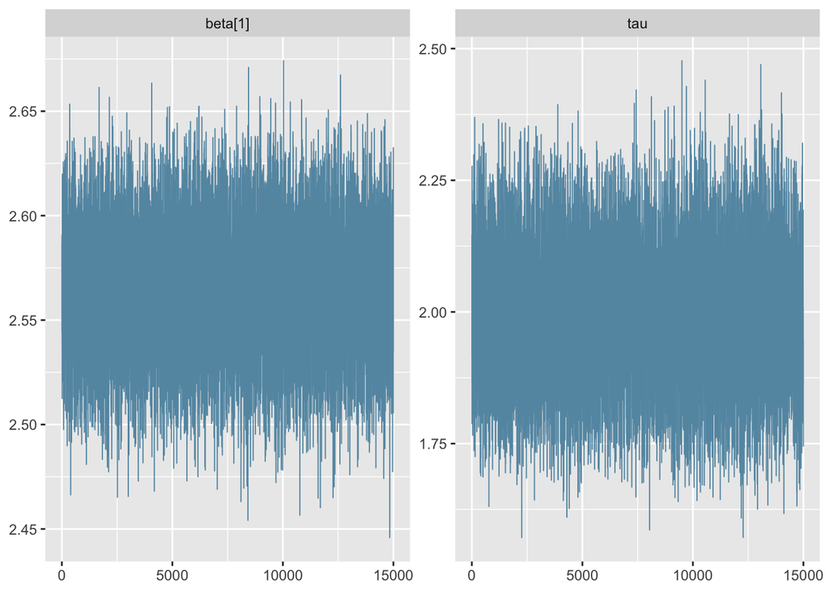

```r
jags.mcmc = as.mcmc(jags.fit)
mcmc_trace(jags.mcmc, pars = c("beta[1]", "tau"))
```

From `beta[1]` and `tau` in the fitted MCMC chain, we can see that the parameters are converged because it is well-mixed, no zig-zag, and the model also shows an white-noise like error term `tau`, which suggests that the covariates are independent.

### c) Posterior inferences

The inferred posterior paramters are listed below:

```r
jags.fit
```

```
## Inference for Bugs model at "4", fit using jags,
##  1 chains, each with 20000 iterations (first 5000 discarded)
##  n.sims = 15000 iterations saved
##                mu.vect sd.vect     2.5%      25%      50%      75%    97.5%
## FEV20ns          6.883   0.788    5.317    6.358    6.888    7.415    8.389
## FEV20s           3.873   0.762    2.401    3.349    3.876    4.382    5.379
## beta[1]          2.564   0.029    2.507    2.545    2.564    2.584    2.620
## beta[2]          0.658   0.102    0.458    0.588    0.659    0.727    0.858
## beta[3]          0.216   0.017    0.183    0.205    0.216    0.227    0.249
## beta[4]         -0.184   0.023   -0.229   -0.199   -0.184   -0.168   -0.139
## meanFEVns[10]    4.727   0.169    4.396    4.613    4.725    4.839    5.059
## meanFEVns[11]    4.943   0.186    4.580    4.819    4.942    5.067    5.308
## meanFEVns[12]    5.159   0.202    4.763    5.025    5.158    5.294    5.557
## meanFEVns[13]    5.375   0.219    4.946    5.230    5.373    5.522    5.806
## meanFEVns[14]    5.592   0.235    5.131    5.435    5.590    5.749    6.056
## meanFEVns[15]    5.808   0.252    5.314    5.640    5.806    5.976    6.304
## meanFEVns[16]    6.024   0.268    5.498    5.846    6.022    6.203    6.552
## meanFEVns[17]    6.240   0.285    5.682    6.052    6.238    6.431    6.801
## meanFEVns[18]    6.457   0.302    5.865    6.256    6.454    6.658    7.050
## meanFEVns[19]    6.673   0.318    6.048    6.462    6.671    6.886    7.300
## meanFEVns[7]     4.078   0.120    3.842    3.997    4.077    4.158    4.314
## meanFEVns[8]     4.294   0.136    4.026    4.202    4.293    4.385    4.562
## meanFEVns[9]     4.510   0.153    4.211    4.408    4.509    4.612    4.810
## meanFEVs[10]     3.547   0.135    3.282    3.456    3.547    3.639    3.811
## meanFEVs[11]     3.580   0.148    3.287    3.480    3.580    3.680    3.870
## meanFEVs[12]     3.613   0.162    3.293    3.503    3.613    3.722    3.931
## meanFEVs[13]     3.645   0.176    3.297    3.526    3.646    3.764    3.993
## meanFEVs[14]     3.678   0.191    3.304    3.549    3.678    3.806    4.054
## meanFEVs[15]     3.710   0.206    3.307    3.571    3.710    3.849    4.116
## meanFEVs[16]     3.743   0.221    3.309    3.594    3.743    3.891    4.178
## meanFEVs[17]     3.775   0.236    3.314    3.617    3.776    3.934    4.239
## meanFEVs[18]     3.808   0.251    3.317    3.638    3.808    3.977    4.301
## meanFEVs[19]     3.841   0.266    3.322    3.661    3.841    4.020    4.361
## meanFEVs[7]      3.450   0.100    3.252    3.381    3.450    3.518    3.645
## meanFEVs[8]      3.482   0.111    3.264    3.407    3.483    3.557    3.698
## meanFEVs[9]      3.515   0.122    3.276    3.432    3.515    3.598    3.752
## tau              1.988   0.121    1.756    1.905    1.984    2.068    2.236
## deviance      1408.083  16.982 1374.876 1396.636 1408.074 1419.440 1441.622
##
## DIC info (using the rule, pD = var(deviance)/2)
## pD = 144.2 and DIC = 1552.3
## DIC is an estimate of expected predictive error (lower deviance is better).
```

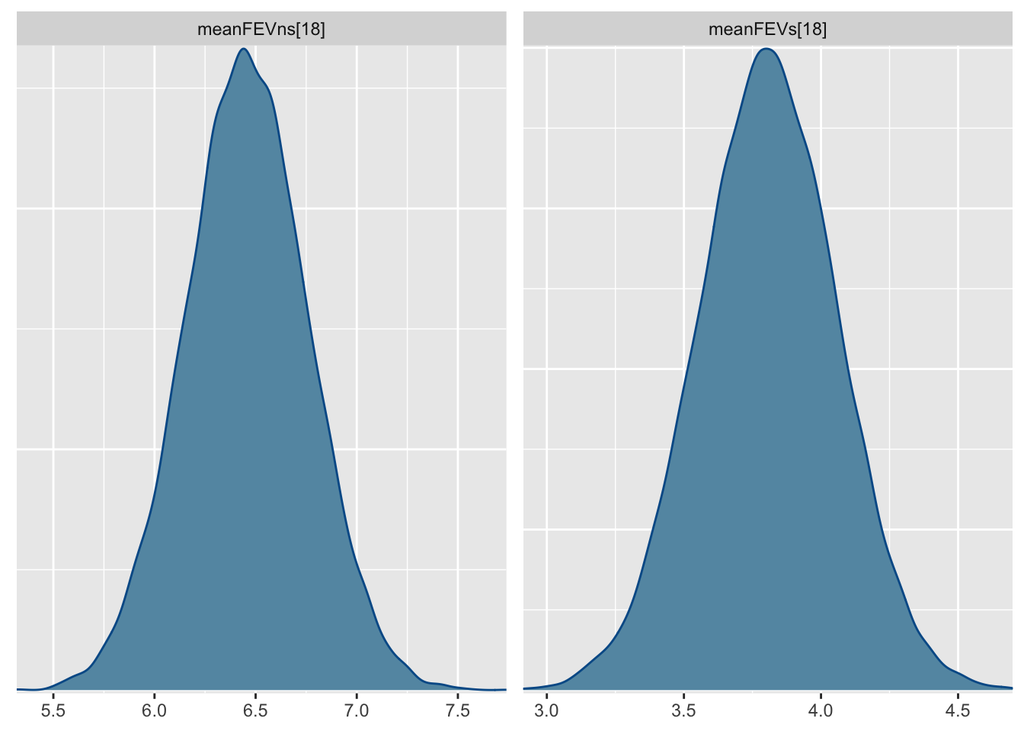

```r
library(bayesplot)
par(mfrow=c(1,2))

mcmc_dens(jags.mcmc, pars=c("meanFEVns[18]", "meanFEVs[18]"))
```

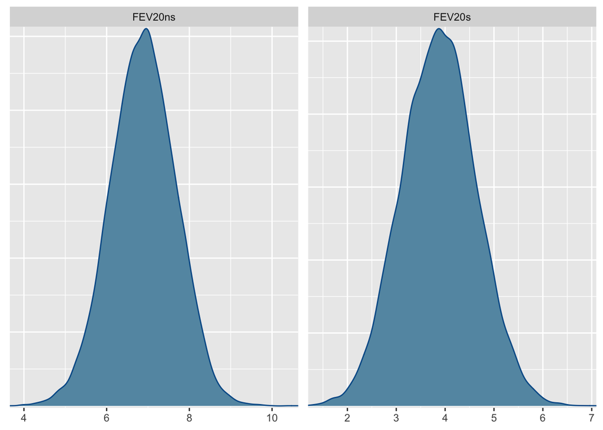

```r
mcmc_dens(jags.mcmc, pars=c("FEV20ns", "FEV20s"))
```

From the plot above, we can see that non-smokers are higher in both posterior FEV of 18-yrs-old group and predictive FEV of 20-yrs-old population.

### d) normal FEV ranges for several different types of adolescents

The FEV ranges of non-smokers and smokers for different ages are shown below:

```r
df_mcmc = data.frame(jags.mcmc[[1]])  %>%
  select(starts_with("meanFEV"))
colnames(df_mcmc) <- gsub('meanFEVs.', 'smoker age ', colnames(df_mcmc), fixed=TRUE)
colnames(df_mcmc) <- gsub('meanFEVns.', 'non smoker age ', colnames(df_mcmc), fixed=TRUE)
df_mcmc %>%
  lapply(quantile, prob = c(0.05, 0.95), na.rm = TRUE) %>%
  data.frame() %>%
  t() %>%
  kable()
```

[output not shown]

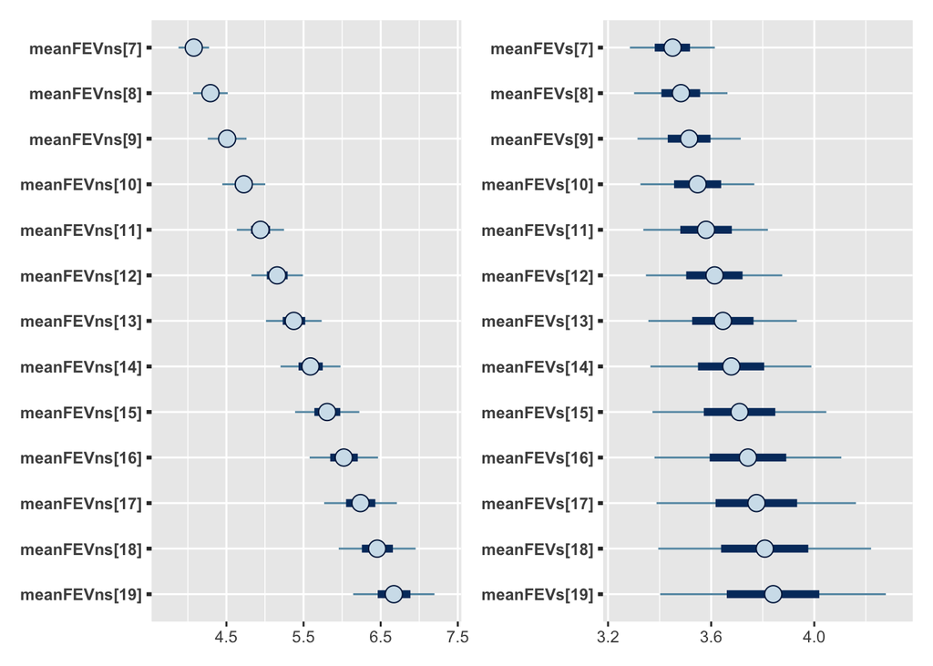

```r
color_scheme_set("blue")
par(mfrow=c(1,2))
p1 = mcmc_intervals(jags.mcmc, pars = c("meanFEVns[7]","meanFEVns[8]","meanFEVns[9]","meanFEVns[10]","meanFEVns[11]", "meanFEVns[12]", "meanFEVns[13]", "meanFEVns[14]", "meanFEVns[15]", "meanFEVns[16]", "meanFEVns[17]", "meanFEVns[18]", "meanFEVns[19]"))
p2 = mcmc_intervals(jags.mcmc, pars = c("meanFEVs[7]","meanFEVs[8]","meanFEVs[9]","meanFEVs[10]","meanFEVs[11]", "meanFEVs[12]", "meanFEVs[13]", "meanFEVs[14]", "meanFEVs[15]", "meanFEVs[16]", "meanFEVs[17]", "meanFEVs[18]", "meanFEVs[19]"))
p1 + p2
```

### e) Sensitivity Analysis

By changing the `a = b = 0.001` to `a = b = 0.1`, we perfromed same pipeline, and got the ranges of FEV as follows, which do not show significant changes compared with previous one.

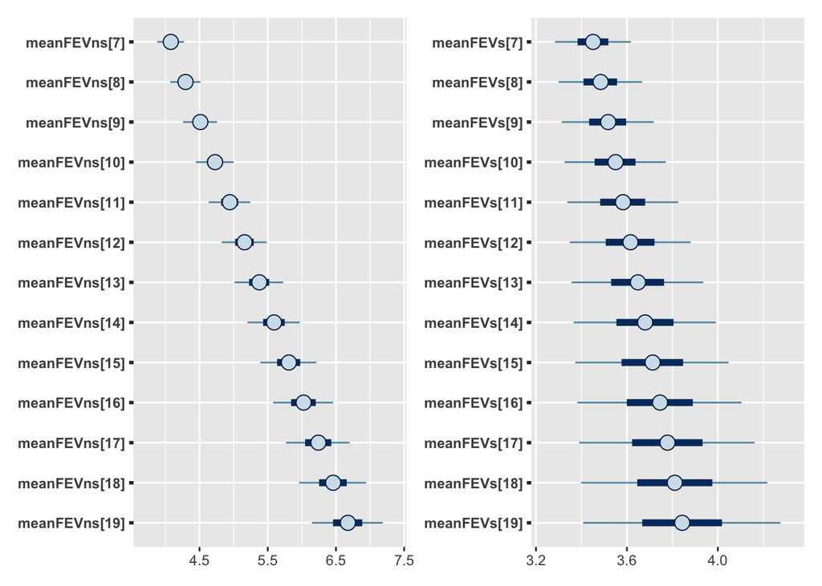

```r
jags.data=list(
  Y=FEV,
  Xmat=X.mat,
  r=dim(X.mat)[2],
  n=dim(X.mat)[1],
  beta0=beta0,
  C0inv=C0inv,
  a=0.1, b=0.1## diffuse prior
)
jags.fit <- jags(data=jags.data, parameters.to.save = jags.param,
model.file=textConnection(model_reg), n.iter=20000, n.chains=1, n.burnin=5000, n.thin=1, DIC=T, digits=6)
jags.mcmc = as.mcmc(jags.fit)
par(mfrow=c(1,2))
p1 = mcmc_intervals(jags.mcmc, pars = c("meanFEVns[7]","meanFEVns[8]","meanFEVns[9]","meanFEVns[10]","meanFEVns[11]", "meanFEVns[12]", "meanFEVns[13]", "meanFEVns[14]", "meanFEVns[15]", "meanFEVns[16]", "meanFEVns[17]", "meanFEVns[18]", "meanFEVns[19]"))
p2 = mcmc_intervals(jags.mcmc, pars = c("meanFEVs[7]","meanFEVs[8]","meanFEVs[9]","meanFEVs[10]","meanFEVs[11]", "meanFEVs[12]", "meanFEVs[13]", "meanFEVs[14]", "meanFEVs[15]", "meanFEVs[16]", "meanFEVs[17]", "meanFEVs[18]", "meanFEVs[19]"))
p1 + p2
```

### f) Summary the Analysis

Above, we constructed a linear model by using age, smoke, and their interaction as predictor. For the priors, we used BCJ priors for $\beta$(coefficients), and Gamma prior for $\tau$ (error term). From the inferred and predictive FEVs, we can see that smokers generally have lower FEVs than non-smokers, and as the age increasing, FEV is increasing as well.

# EX 9.22

```r
coleman = read_csv(file="Coleman.csv")
attach(coleman)
jags.data=list(
  y=y,
  x=x,
  n=dim(coleman)[1],
  b=0.01, c=0.001## diffuse prior
)

model_reg <-
"model{
  for(i in 1:n){
      y[i] ~ dnorm(mu[i], tau)
      mu[i] <- beta[1] + beta[2]* x[i]
  }
  for(j in 1:2){
    beta[j] ~ dmnorm(0, b)
  }

  tau ~ dgamma(c, c)
  pred = beta[1] + beta[2]*(-16.04)
}"

jags.param=c("tau", "beta", "pred")
```

```r
jags.fit <- jags(data=jags.data, parameters.to.save = jags.param,
                 model.file=textConnection(model_reg), n.iter=20000, n.chains=1,
                 n.burnin=5000,n.thin=1, DIC=T, digits=6)
```

[figure not shown]

From the fitted result above, `x` and `y` are positively correlated with 0.9271611 Pearson correlation.

```r
jags.fit
```

```
## Inference for Bugs model at "4", fit using jags,
##  1 chains, each with 20000 iterations (first 5000 discarded)
##  n.sims = 15000 iterations saved
##          mu.vect sd.vect   2.5%    25%    50%    75%  97.5%
## beta[1]   33.209   0.566 32.083 32.843 33.217 33.584 34.303
## beta[2]    0.564   0.057  0.453  0.528  0.565  0.602  0.676
## pred      24.159   1.218 21.774 23.360 24.158 24.969 26.544
## tau        0.198   0.066  0.090  0.151  0.191  0.238  0.347
## deviance  90.200   2.691 87.147 88.240 89.513 91.410 97.220
##
## DIC info (using the rule, pD = var(deviance)/2)
## pD = 3.6 and DIC = 93.8
## DIC is an estimate of expected predictive error (lower deviance is better).
```

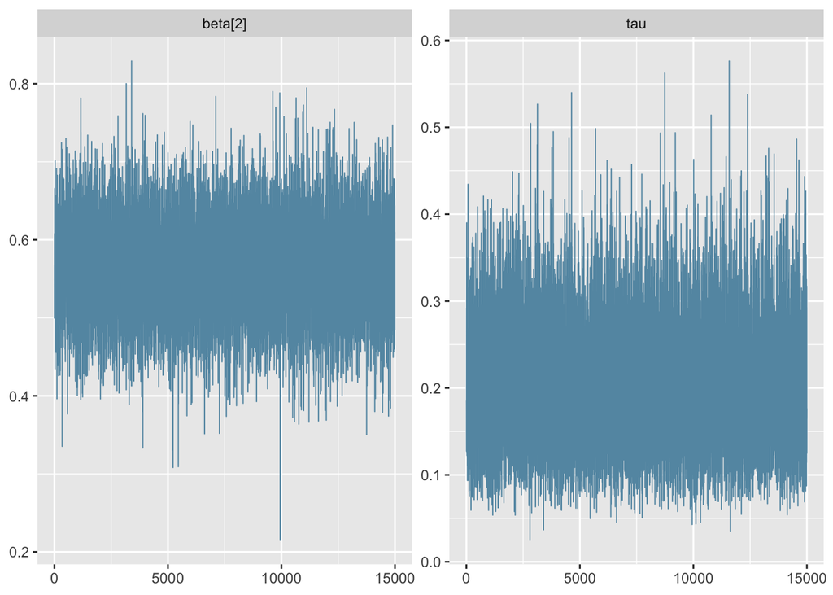

```r
jags.mcmc = as.mcmc(jags.fit)
mcmc_trace(jags.mcmc, pars = c("beta[2]", "tau"))
```

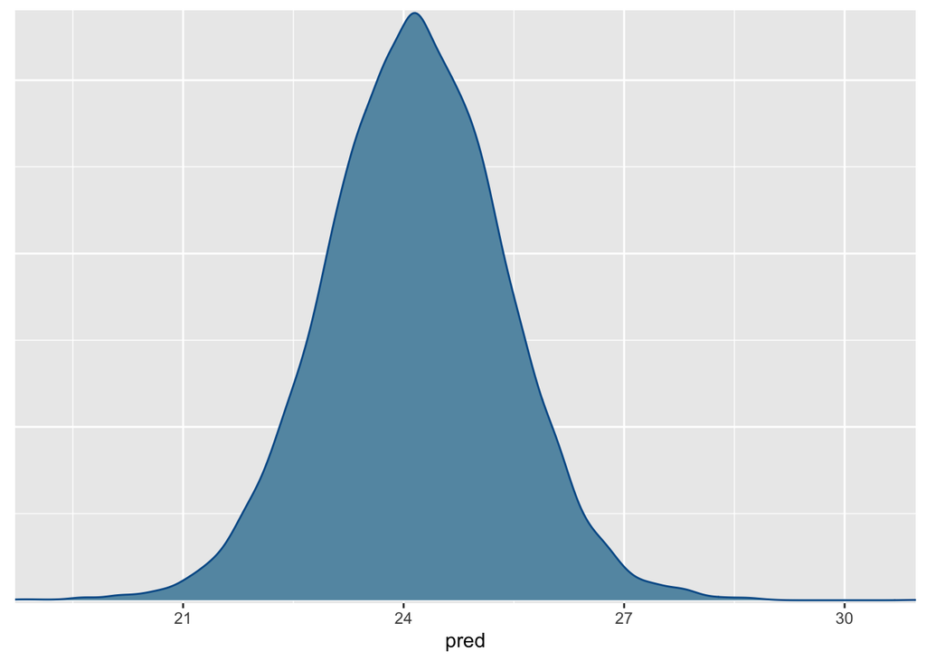

```r
mcmc_dens(jags.mcmc, pars = c("pred"))
```

#### I am not surprised that higher socioeconomic status were positively associated with higher test scores, because they can receive better education resource(environment, teaching method, etc.)